# End of semester project for Evolutional Algorithms @ University of Wroclaw, 2020

## Tapa Solver

### Description of the project

Tapa is a puzzle invented in Turkey. Rules are following: Shade some empty cells black to create a single connected wall. Numbers in a cell indicate the length of consecutive shaded blocks in the neighboring cells. If there is more than one number in a cell, then there must be at least one white (unshaded) cell between the black cell groups. Cells with numbers cannot be shaded, and the shaded cells cannot form a 2×2 square anywhere in the grid. The picture below shows a grid with correct solution.

The main goal of the project is to find a good evolutional approach to solve any Tapa puzzle.

```python
import cairosvg
from collections import namedtuple
import cv2
import drawSvg as draw
from itertools import combinations_with_replacement, combinations, chain, product
import numpy as np
import matplotlib.pyplot as plt
import pickle
from PIL import Image
from tqdm import tqdm_notebook

TapaInstance = namedtuple('TapaInstance', 'size coords hints')
```

```python
sample_instances = [
    TapaInstance(size=4, coords=[[1,1]], hints=[[1,2,2]]),
    TapaInstance(size=6, coords=[[0,0], [0,3], [2,4], [3,1], [5,2], [5,5]], hints=[[2], [1,1,1], [7], [1,5], [1,3], [1,1]]),
    TapaInstance(size=6, coords=[[0,3], [1,0], [1,5], [4,0], [4,5], [5,2]], hints=[[4], [1,3], [1,2], [3], [2], [3]]),
    TapaInstance(size=7, coords=[[0,5], [1,1], [3,2], [3,4], [5,5], [6,1]], hints=[[2,2], [1,1,1], [2,4], [1,3,1], [6], [1,3]]),
    TapaInstance(size=7, coords=[[0,6], [2,2], [2,4], [4,2], [4,4], [6,0]], hints=[[1], [3], [3,3], [4], [1,1,2], [2]]),
    TapaInstance(size=7, coords=[[1,1], [1,3], [1,5], [5,1], [5,3], [5,5]], hints=[[2,2], [2,2], [2,3], [3,3], [2,4], [2,2]]),
    TapaInstance(size=7, coords=[[0,1], [0,6], [2,3], [3,1], [3,5], [4,3], [6,0], [6,5]], hints=[[3], [1], [6], [1,4], [3,3], [1,1,1], [1], [3]]),
    TapaInstance(size=7, coords=[[1,3], [2,1], [2,5], [3,3], [4,1], [4,5], [5,3]], hints=[[7], [1,2,2], [3,3], [1,5], [1,5], [2,3], [3,3]]),
    TapaInstance(size=8, coords=[[0,3], [0,4], [3,0], [3,3], [3,4], [7,3], [4,0], [4,3], [4,4], [4,7], [7,3], [7,4]], hints=[[3], [2], [3], [1,1,1], [3], [2], [2], [3], [1,1,1], [3], [2], [3]]),
    TapaInstance(size=8, coords=[[1,0], [1,3], [1,4], [1,7], [2,3], [2,4], [3,1], [3,6], [4,2], [4,5], [5,2], [5,5], [6,1], [6,6]], hints=[[3], [1,3], [4], [3], [3], [1,1], [3], [4], [1,2], [2], [2], [1,2], [4], [6]]),
    TapaInstance(size=8, coords=[[1,1], [1,5], [2,3], [3,7], [4,0], [5,4], [6,2], [6,6]], hints=[[2], [3], [1,1,2], [3], [3], [2,3], [4], [4]]),
    TapaInstance(size=9, coords=[[1,3], [2,1], [2,6], [4,2], [4,6], [6,2], [6,7], [7,5]], hints=[[4], [1,2,2], [4], [1,1], [1,1,1], [1], [3], [2,2]]),
    TapaInstance(size=10, coords=[[0,1], [1,0], [1,4], [1,8], [3,3], [4,2], [5,7], [6,6], [8,1], [8,5], [8,9], [9,8]], hints=[[1], [1], [1,1,1], [1,1,1], [1], [1], [1], [1,1], [1,1,1], [1,1,1], [1], [1]]),
    TapaInstance(size=10, coords=[[0,9], [1,2], [1,4], [1,6], [3,2], [3,5], [3,7], [6,2], [6,4], [6,7], [8,3], [8,5], [8,7], [9,0]], hints=[[2], [2,3], [2,3], [2,2], [3,3], [1,5], [6], [2,4], [5], [2,3], [3,3], [1,4], [1,4], [2]]),
    TapaInstance(size=12, coords=[[1,2], [1,8], [2,5], [2,10], [3,2], [4,4], [4,7], [5,9], [6,2], [7,4], [7,7], [8,9], [9,1], [9,6], [10,3], [10,9]], hints=[[2,4], [1,5], [2,2], [1,5], [2,4], [7], [6], [3,3], [2,2], [6], [6], [2,3], [3,3], [2,2], [7], [1,2,2]]),
    TapaInstance(size=12, coords=[[1,2], [1,4], [1,6], [1,9], [3,3], [3,6], [3,9], [4,1], [4,4], [5,7], [5,9], [6,2], [6,4], [7,7], [7,10], [8,2], [8,5], [8,8], [10, 2], [10, 5], [10,7], [10,9]], hints=[[3,3], [1,4], [2,3], [2,4], [2,2], [2,4], [1,5], [1,3], [3], [7], [8], [2,2], [3], [1,5], [1,5], [1,2], [1,5], [1,5], [5], [5], [5], [5]]),
]
```

```python
def draw_grid(instance, solution=None):
    margin = 25
    cell_size = 50
    out_size = instance.size * cell_size + 2 * margin
    grid_size = instance.size * cell_size
    d = draw.Drawing(out_size, out_size, origin=(0,0), displayInline=False)
    d.append(draw.Rectangle(0, 0, out_size, out_size, fill='#FFFFFF'))

    if solution is not None:
        for idx, jdx in product(range(instance.size), range(instance.size)):
            if solution.T[idx, jdx] == 1:
                 d.append(draw.Rectangle(idx*cell_size+margin, (instance.size-jdx - 1)*cell_size+margin, cell_size, cell_size, fill='#AAAAAA'))

    p = draw.Path(stroke_width=3, fill='black', fill_opacity=0.0, stroke='black')
    p.M(margin, margin)
    p.l(grid_size, 0)
    p.l(0, grid_size)
    p.l(-grid_size, 0)
    p.Z()
    d.append(p)

    for idx in range(instance.size - 1):
        p = draw.Path(stroke_width=1, fill='black', fill_opacity=0.0, stroke='black')
        p.M(margin + cell_size * (idx + 1), margin); p.l(0,  grid_size)
        d.append(p)

        p = draw.Path(stroke_width=1, fill='black', fill_opacity=0.0, stroke='black')
        p.M(margin, margin + cell_size * (idx + 1)); p.l(grid_size, 0)
        d.append(p)


    for (idx, jdx), hint in zip(instance.coords, instance.hints):
        if len(hint) < 3:
            t = draw.Text(str(hint).replace(',','')[1:-1], 25, cell_size * (jdx + 1), cell_size * (instance.size - idx) + 3, center=True, fill='black', font_family='monospace')
            d.append(t)

        else:
            t = draw.Text(str(hint[:2]).replace(',','')[1:-1], 15, cell_size * (jdx + 1), cell_size * (instance.size - idx) + 14, center=True, fill='black', font_family='monospace')
            d.append(t)
            t = draw.Text(str(hint[2:]).replace(',','')[1:-1], 15, cell_size * (jdx + 1), cell_size * (instance.size - idx) - 10, center=True, fill='black', font_family='monospace')
            d.append(t)

    return d
```

```python
def show_grids(instances, solutions=None, figsize=(20,12)):
    plt.figure(figsize=figsize)
    for i in range(len(instances)):
        plt.subplot(len(instances) // 4 + 1, 4, i + 1)

        ind = None
        if solutions is not None:
            ind = solutions[i, :].reshape((instances[i].size, -1))

        d = draw_grid(instances[i], ind)
        pngData = cairosvg.svg2png(bytestring=d.asSvg())
        nparr = np.frombuffer(pngData, np.uint8)
        img = cv2.imdecode(nparr, flags=1)
        plt.imshow(img)

    plt.show()
```

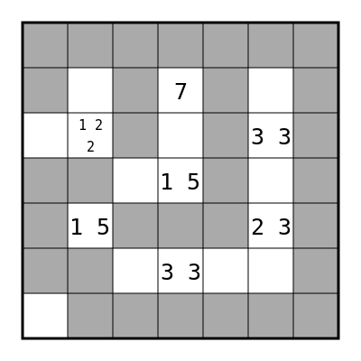

```python
solution = np.array([
    [1,1,1,1,1,1,1],
    [1,0,1,0,1,0,1],
    [0,0,1,0,1,0,1],
    [1,1,0,0,1,0,1],
    [1,0,1,1,1,0,1],
    [1,1,0,0,0,0,1],
    [0,1,1,1,1,1,1]
])
draw_grid(sample_instances[7], solution).rasterize()
```

## Objective function

The objective function will be constructed in a way that the more rules for correct solution an individual breaks, the less a value of the function is. We can assign values of penalty for each type of error, to point out which mistakes are somewhat worse, and which not so bad.

```python
BLACK_SQUARE_PENALTY = 10
NOT_CONNECTED_PENALTY = 5
CLUE_COVERED_PENALTY = 10
BADLY_HINT_PENALTY = 4
```

```python
def fit(hints, neigh, strict):
    if len(hints) == 1 and hints[0] == 8:
        return sum(neigh) == 8

    d = {}
    for h in hints:
        if h == 0:
            continue
        if h not in d:
            d[h] = 0
        d[h] += 1
    n = len(neigh)

    if strict == False:
        neigh = neigh + neigh
        for i in range(n):
            if neigh[i] == 0:
                neigh = neigh[i:n+i]
                break
        if i == n:
            return sum(hints) == 0

    i = 0
    while i < n:
        length = 0
        while i < n and neigh[i] == 1:
            i += 1
            length += 1
        if length > 0:
            if length in d and d[length] > 0:
                d[length] -= 1
            else:
                return False
        i += 1

    for k in d:
        if d[k] > 0:
            return False

    return True

def objective_function(p, instance):
    score = 0
    p = p.reshape((instance.size,instance.size))

    # bez czarnych we wskazowkach
    for idx, jdx in instance.coords:
        if p[idx, jdx] == 1:
            score -= CLUE_COVERED_PENALTY

    # bez kwadratow 2x2
    for idx, jdx in product(range(instance.size - 1), range(instance.size - 1)):
        if p[idx:idx+2, jdx:jdx+2].sum() == 4:
            score -= BLACK_SQUARE_PENALTY

    # spojnosc
    queue = []
    copied = p.copy()
    parts = 0
    for idx, jdx in product(range(instance.size), range(instance.size)):
        if copied[idx, jdx] == 1:
            parts += 1
            queue.append((idx, jdx))
            while len(queue) > 0:
                (i,j), queue = queue[0], queue[1:]
                copied[i,j] = 0
                if i > 0 and copied[i - 1, j] == 1:
                    queue.append((i - 1, j))
                if j > 0 and copied[i, j - 1] == 1:
                    queue.append((i, j - 1))
                if i < instance.size - 1 and copied[i + 1, j] == 1:
                    queue.append((i + 1, j))
                if j < instance.size - 1 and copied[i, j + 1] == 1:
                    queue.append((i, j + 1))

    score -= abs(parts - 1) * NOT_CONNECTED_PENALTY

    for (i,j), hint in zip(instance.coords, instance.hints):
        if 0 < i < instance.size - 1 and 0 < j < instance.size - 1:
            nei = [
                p[i + 1, j + 1],
                p[i, j + 1],
                p[i - 1, j + 1],
                p[i - 1, j],
                p[i - 1, j - 1],
                p[i, j - 1],
                p[i + 1, j - 1],
                p[i + 1, j]
            ]
            strict = False
        else:
            strict = True
            if i == 0 and j == 0:
                nei = [
                    p[1, 0],
                    p[1, 1],
                    p[0, 1]
                ]
            elif i == 0 and j < instance.size - 1:
                nei = [
                    p[0, j - 1],
                    p[1, j - 1],
                    p[1, j],
                    p[1, j + 1],
                    p[0, j + 1]
                ]

            elif i == 0 and j == instance.size - 1:
                nei = [
                    p[0, j - 1],
                    p[1, j - 1],
                    p[1, j - 1]
                ]

            elif j == instance.size - 1 and i < instance.size - 1:
                nei = [
                    p[i - 1, j], p[i - 1, j - 1], p[i, j - 1], p[i + 1, j - 1], p[i + 1, j]
                ]

            elif j == instance.size - 1 and i == instance.size - 1:
                nei = [
                    p[i - 1, j], p[i - 1, j - 1], p[i, j - 1]
                ]

            elif i == instance.size - 1 and j > 0:
                nei = [
                    p[i, j - 1], p[i - 1, j - 1], p[i - 1, j], p[i - 1, j + 1], p[i, j + 1]
                ]

            elif i == instance.size - 1 and j == 0:
                nei = [
                    p[i - 1, 0], p[i - 1, 1], p[i, 1]
                ]

            elif j == 0 and i > 0:
                nei = [
                    p[i - 1, 0], p[i - 1, 1], p[i, 1], p[i + 1, 1], p[i + 1, 0]
                ]

            else:
                raise ValueError("huh {} {}".format(i,j))

        # zgodnosc z hintami
        if not fit(hint, nei, strict=strict):
            score -= BADLY_HINT_PENALTY

    return score
```

## Approach no. 1: Population-based incremental learning (PBIL)

For each cell in a grid an individual contains one number indicating probability of painting this cell in the final solution.

```python
class PBIL():
    def __init__(self, d, N, iterations, function, theta1, theta2, theta3, instance, log_frequency=100):
        self.d = d
        self.N = N
        self.iterations = iterations
        self.target_func = function
        self.theta1 = theta1
        self.theta2 = theta2
        self.theta3 = theta3
        self.log_frequency = log_frequency
        self.instance = instance


    def initial_vector(self):
        return np.full(self.d, fill_value=0.5)

    def binary_random(self, p):
        if np.random.rand() < p:
            return 1
        return 0

    def random_individual(self, p):
        return (np.random.rand(self.d) < p).astype(int)

    def random_population(self, p):
        return np.array([self.random_individual(p) for i in range(self.N)])

    def evaluate_population(self, population):
        scores = [self.target_func(population[i,:]) for i in range(self.N)]
        return np.min(scores), np.average(scores), np.max(scores)

    def get_best_individual(self, population):
        index = np.argmax([self.target_func(population[i,:]) for i in range(self.N)])
        return population[index,:]

    def solve(self, verbose=False, no_tqdm=False):
        ppb_vector = self.initial_vector()
        population = self.random_population(ppb_vector)

        score = self.evaluate_population(population)
        self.scores = [score]
        self.vectors = [ppb_vector]

        if no_tqdm:
            to_iterate = range(self.iterations)
        else:
            to_iterate = tqdm_notebook(range(self.iterations))

        for iteration in to_iterate:
            best_individual = self.get_best_individual(population)

            old_ppb_vector = ppb_vector.copy()
            ppb_vector = ppb_vector * (1 - self.theta1) + best_individual * self.theta1

            for idx in range(self.d):
                if np.random.rand() < self.theta2:
                    ppb_vector[idx] = ppb_vector[idx] * (1 - self.theta3) + self.binary_random(0.5) * self.theta3

            population = self.random_population(ppb_vector)
            score = self.evaluate_population(population)

            self.scores.append(score)
            self.vectors.append(tuple(ppb_vector))

            self.best = best_individual
            self.best_score = self.target_func(self.best)

            if np.mod(iteration, self.log_frequency) == 0 and verbose:
                print("Iteration %04d : best score = %0.2f, mean score = %0.2f, mean move = %0.4f" % (iteration, self.best_score, score[1], np.sqrt(((old_ppb_vector - ppb_vector) ** 2).sum()) ))

            if self.best_score == 0:
                break

    def show_stats(self):
        print('Najlepszy osobnik uzyskał rezultat: {}'.format(self.best_score))
        plt.figure(figsize=(12, 4))
        plt.subplot(121)
        plt.plot(self.scores)
        plt.title("Wykres funkcji celu")
        plt.subplot(122)
        plt.plot(self.vectors)
        plt.title("Wykres wartości prawdopodobieństw")
        plt.show()
        population = np.vstack([self.best, self.random_population(self.vectors[-1])[:3, :]])
        show_grids([self.instance for _ in range(4)], population)
```

```
Najlepszy osobnik uzyskał rezultat: -8
```

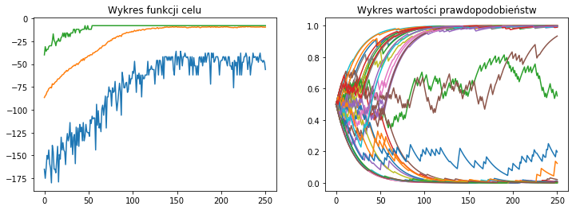

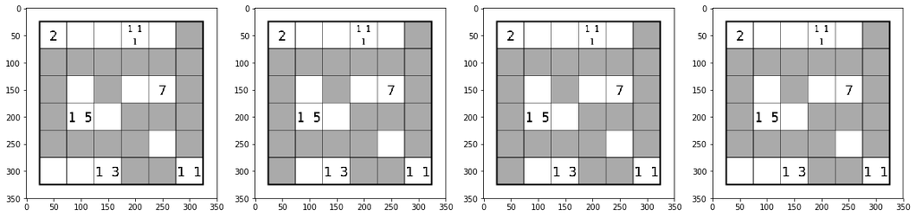

```python
instance = sample_instances[1]; d=instance.size ** 2
pbil = PBIL(
    d=d,
    N=20 * d,
    iterations=250,
    function=lambda x: objective_function(x, instance),
    theta1=0.05,
    theta2=0.05,
    theta3=0.01,
    log_frequency=50,
    instance=instance)
pbil.solve(verbose=False)
pbil.show_stats()
```

```
Najlepszy osobnik uzyskał rezultat: -8
```

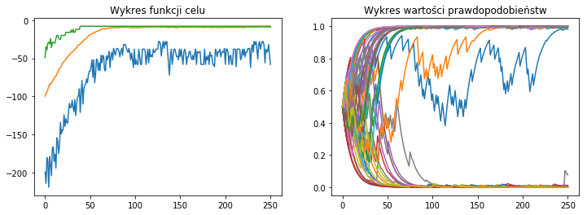

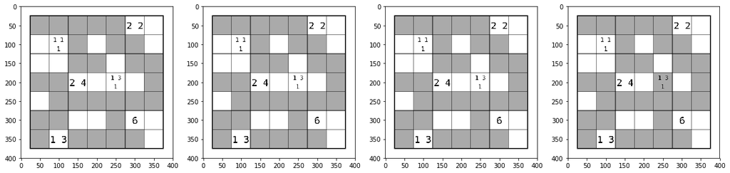

```python
instance = sample_instances[3]; d=instance.size ** 2
pbil = PBIL(
    d=d,
    N=20 * d,
    iterations=250,
    function=lambda x: objective_function(x, instance),
    theta1=0.1,
    theta2=0.05,
    theta3=0.01,
    log_frequency=50,
    instance=instance)
pbil.solve(verbose=False)
pbil.show_stats()
```

```
Najlepszy osobnik uzyskał rezultat: -9
```

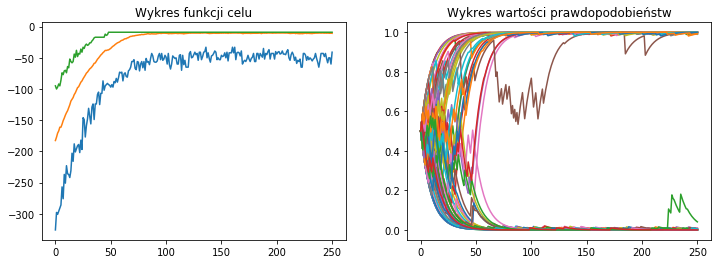

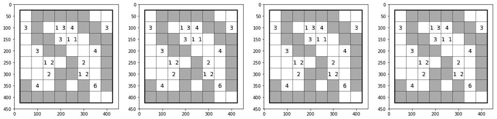

```python
instance = sample_instances[9]; d=instance.size ** 2
pbil = PBIL(
    d=d,
    N=20 * d,
    iterations=250,
    function=lambda x: objective_function(x, instance),
    theta1=0.1,
    theta2=0.05,
    theta3=0.01,
    log_frequency=50,
    instance=instance)
pbil.solve(verbose=False)
pbil.show_stats()
```

## Approach no. 2: Simple Genetic Algorithm (SGA)

The genotype is simple: for each cell we hold 1 or 0, to indicate if the cell will be painted or not.

### Simple crossover and mutation operators

Let's check the easiest operators: single- and multipoint crossover and a mutation flipping each bit with low probability.

```python
def simple_crossover(p, q):  # randomly split into two, combine different parts
    k = np.random.choice(len(p))
    w = np.zeros_like(p)
    v = np.zeros_like(q)
    w[:k] = p[:k]
    w[k:] = q[k:]
    v[:k] = q[:k]
    v[k:] = p[k:]

    return w, v

def multipoint_crossover(p, q):
    if len(p) <= 1:
        return q, p
    k = np.random.choice(range(1, len(p)))
    idx = sorted(np.random.choice(len(p), k, replace=False))
    w = np.zeros_like(p)
    v = np.zeros_like(q)

    for i in range(len(idx)):
        if i == 0:
            w[:idx[i]] = p[:idx[i]]
            v[:idx[i]] = q[:idx[i]]

        elif i % 2 == 1:
            w[idx[i-1]:idx[i]] = q[idx[i-1]:idx[i]]
            v[idx[i-1]:idx[i]] = p[idx[i-1]:idx[i]]

        elif i % 2 == 0:
            w[idx[i-1]:idx[i]] = p[idx[i-1]:idx[i]]
            v[idx[i-1]:idx[i]] = q[idx[i-1]:idx[i]]

        if i == len(idx) - 1 and i % 2 == 1:
            w[idx[i]:] = p[idx[i]:]
            v[idx[i]:] = q[idx[i]:]

        if i == len(idx) - 1 and i % 2 == 0:
            w[idx[i]:] = q[idx[i]:]
            v[idx[i]:] = p[idx[i]:]

    return w, v

def simple_mutation(p, ppb):
    for i in range(len(p)):
        if np.random.random() < ppb:
            p[i] = 1 - p[i]
    return p
```

```python
class SGA:
    def __init__(self, instance, func):
        self.instance = instance
        self.func = func

    def solve(self,
             number_of_iterations=250,
             population_size=500,
             crossover_probability=0.95,
             mutation_probability=0.05,
             individual_constructor=lambda instance: np.random.choice(2, instance.size ** 2),
             crossover_method=simple_crossover,
             mutation_method=simple_mutation,
             log_frequency=100,
             max_found_solutions=1,
             verbose=False,
             reset_on_stuck=False,
             reset_after=25,
             reset_function=None,
             title='',
             no_tqdm=False):

        chromosome_length = len(individual_constructor(self.instance))
        number_of_offspring = population_size

        self.costs = np.zeros(number_of_iterations)
        self.permutations = np.empty((number_of_iterations, chromosome_length), dtype=np.int64)
        self.last_population = np.empty((population_size,chromosome_length), dtype=np.int64)
        current_population = np.empty((population_size,chromosome_length), dtype=np.int64)

        self.critical_individuals = []

        best_objective_value = np.Inf
        best_chromosome = np.zeros((1, chromosome_length))

        # generating an initial population
        for i in range(population_size):
            current_population[i, :] = individual_constructor(self.instance)

        # evaluating the objective function on the current population
        objective_values = np.zeros(population_size)
        for i in range(population_size):
            objective_values[i] = self.func(current_population[i, :])

        iterations_without_changes = 0

        self.successfull_crossovers = []

        if no_tqdm:
            to_iterate = range(number_of_iterations)

        else:
            to_iterate = tqdm_notebook(range(number_of_iterations), desc=title)
        for t in to_iterate:

            # selecting the parent indices by the roulette wheel method
            fitness_values = objective_values.max() - objective_values
            if fitness_values.sum() > 0:
                fitness_values = fitness_values / fitness_values.sum()
            else:
                fitness_values = np.ones(population_size) / population_size
            parent_indices = np.random.choice(population_size, number_of_offspring, True, fitness_values).astype(np.int64)

            # creating the children population
            children_population = np.zeros((number_of_offspring, chromosome_length), dtype=np.int64)
            successes = 0
            for i in range(int(number_of_offspring/2)):
                if np.random.random() < crossover_probability:
                    child1, child2 = crossover_method(current_population[parent_indices[2*i], :].copy(), current_population[parent_indices[2*i+1], :].copy())
                    children_population[2*i, :], children_population[2*i+1, :] = child1, child2

                    best_parent = max(self.func(current_population[parent_indices[2*i], :]), self.func(current_population[parent_indices[2*i + 1], :]))
                    if self.func(child1) > best_parent:
                        successes += 1

                    if self.func(child2) > best_parent:
                        successes += 1

                else:
                    children_population[2*i, :], children_population[2*i+1, :] = current_population[parent_indices[2*i], :].copy(), current_population[parent_indices[2*i+1]].copy()
            if np.mod(number_of_offspring, 2) == 1:
                children_population[-1, :] = current_population[parent_indices[-1], :]


            self.successfull_crossovers.append(successes)
            # mutating the children population
            for i in range(number_of_offspring):
                children_population[i, :] = mutation_method(children_population[i, :], mutation_probability)

            # evaluating the objective function on the children population
            children_objective_values = np.zeros(number_of_offspring)
            for i in range(number_of_offspring):
                children_objective_values[i] = self.func(children_population[i, :])

            # replacing the current population by (Mu + Lambda) Replacement
            objective_values = np.hstack([objective_values, children_objective_values])
            current_population = np.vstack([current_population, children_population])

            I = np.argsort(objective_values)
            current_population = current_population[I[:population_size], :]
            objective_values = objective_values[I[:population_size]]

            self.costs[t] = min(objective_values)
            self.permutations[t, :] = current_population[0, :]

            if self.costs[t] < self.costs[t - 1]:
                self.critical_individuals.append(current_population[0, :])

            if np.mod(t, log_frequency) == 0 and verbose:
                print("Iteration %04d : best score = %0.2f, mean score = %0.2f" % (t, self.costs[t], objective_values.mean()))

            self.last_population = current_population

            if (objective_values == 0).sum() >= max_found_solutions:
                break

            if t > 0 and self.costs[t] < self.costs[t - 1]:
                iterations_without_changes = 0

            if t > 0 and self.costs[t] == self.costs[t - 1]:
                iterations_without_changes += 1

            if iterations_without_changes >= reset_after and reset_on_stuck:
                iterations_without_changes = 0
                for i in range(population_size):
                    refreshed = reset_function(self.instance, current_population[i, :].copy(), k = 4)
                    current_population[i, :] = refreshed
                    objective_values[i] = self.func(current_population[i, :])

        self.best = self.permutations[self.costs.argmin(), :]
        self.best_score = self.func(self.best)

    def show_stats(self):
        plt.plot(self.costs)
        plt.title('Algorytm osiągnął najlepszy wynik równy {}'.format(self.best_score))
        plt.show()

    def show_successes(self):
        plt.plot(self.successfull_crossovers)
        plt.title('Successful crossovers over time')
        plt.show()

    def show_individuals(self, figsize=(20,12), unroll_func=None):
        count = min(len(self.critical_individuals), 12)
        instances = [self.instance for _ in range(count)]
        individuals = []
        if unroll_func is not None:
            individuals = np.asanyarray([unroll_func(self.instance, self.critical_individuals[-idx - 1]) for idx in range(count)][::-1])
        else:
            individuals = np.asanyarray(self.critical_individuals[-count:-1, :])
        show_grids(instances, individuals, figsize=figsize)
```

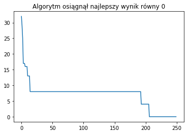

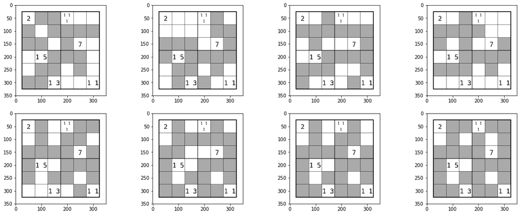

```python
ins = sample_instances[1]
sga = SGA(ins, func=lambda x: -objective_function(x, ins)); d = ins.size ** 2; sga.solve(
    number_of_iterations=250,
    population_size=20 * d,
    crossover_probability=0.9,
    mutation_probability=0.1,
    crossover_method=multipoint_crossover,
    mutation_method=simple_mutation,
    log_frequency=10,
    title='SGA z prostymi operatorami'
)
sga.show_stats()
sga.show_individuals()
```

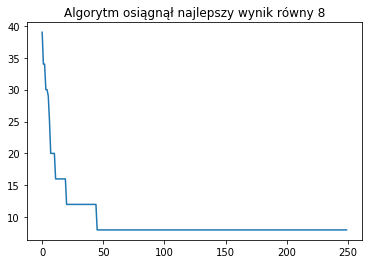

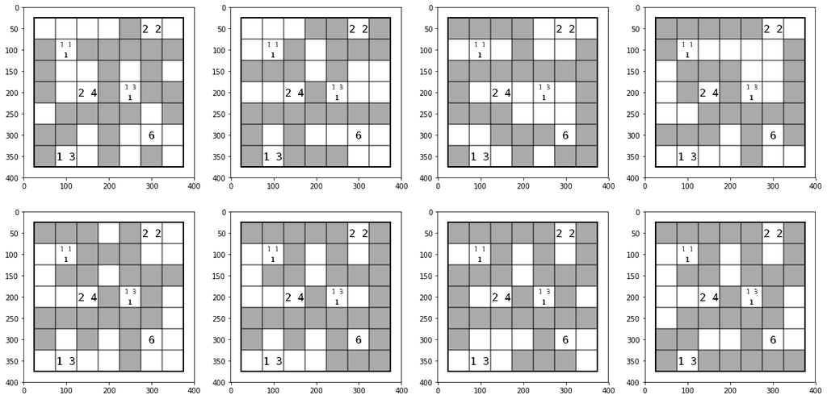

```python
ins = sample_instances[3]
sga = SGA(ins, func=lambda x: -objective_function(x, ins)); d = ins.size ** 2; sga.solve(
    number_of_iterations=250,
    population_size=20 * d,
    crossover_probability=0.95,
    mutation_probability=0.05,
    crossover_method=multipoint_crossover,
    mutation_method=simple_mutation,
    log_frequency=10,
    title='SGA z prostymi operatorami'
)
sga.show_stats()
sga.show_individuals(figsize=(20,15))
```

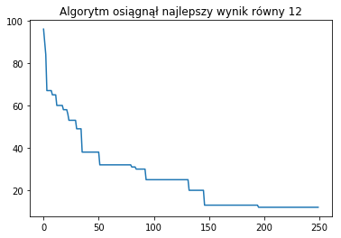

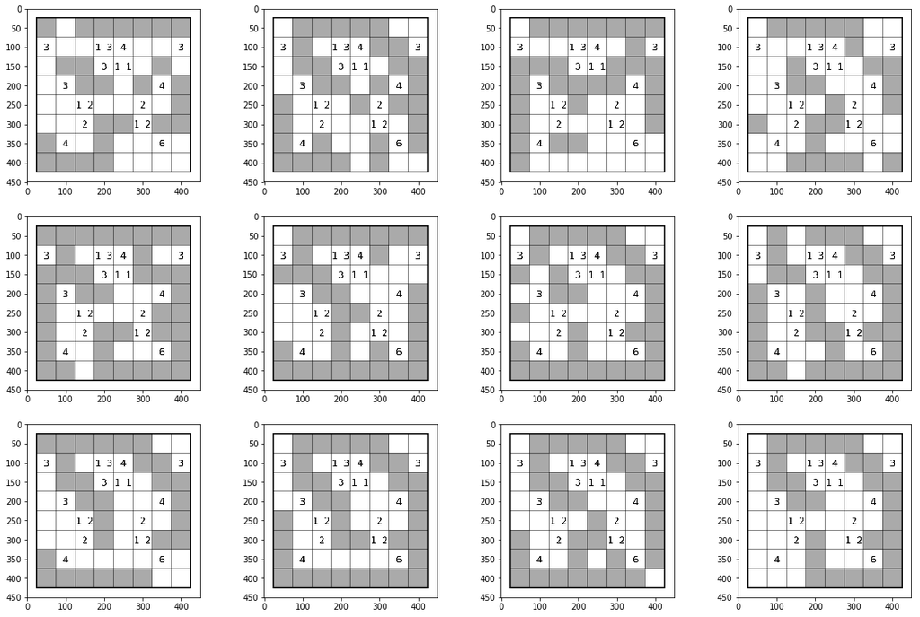

```python
ins = sample_instances[9]
sga = SGA(ins, func=lambda x: -objective_function(x, ins)); d = ins.size ** 2; sga.solve(
    number_of_iterations=250,
    population_size=20 * d,
    crossover_probability=0.95,
    mutation_probability=0.1,
    crossover_method=multipoint_crossover,
    mutation_method=simple_mutation,
    log_frequency=10,
    title='SGA z prostymi operatorami'
)
sga.show_stats()
sga.show_individuals(figsize=(20,18))
```

### Saving row/column of the solution crossover operator

Within crossover we exchange full rows or columns, instead of not connected parts of solution.

```python
def rowcolumn_crossover(p, q):
    n = int(np.sqrt(len(p)))
    p = p.reshape((n, -1))
    q = q.reshape((n, -1))

    w = np.zeros_like(p)
    v = np.zeros_like(q)
    k = np.random.choice(n) + 1
    idx = sorted(np.random.choice(n, k, replace=False))

    if np.random.choice(2) == 0:  # choosing orientation
        # row wise crossover
        for i in range(n):
            if i in idx:
                w[i, :] = p[i, :]
                v[i, :] = q[i, :]
            else:
                w[i, :] = q[i, :]
                v[i, :] = p[i, :]
    else:
        for i in range(n):
            if i in idx:
                w[:, i] = p[:, i]
                v[:, i] = q[:, i]
            else:
                w[:, i] = q[:, i]
                v[:, i] = p[:, i]

    return w.reshape(-1), v.reshape(-1)
```

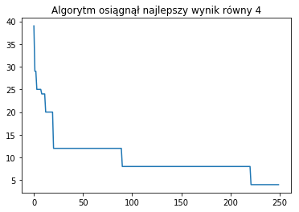

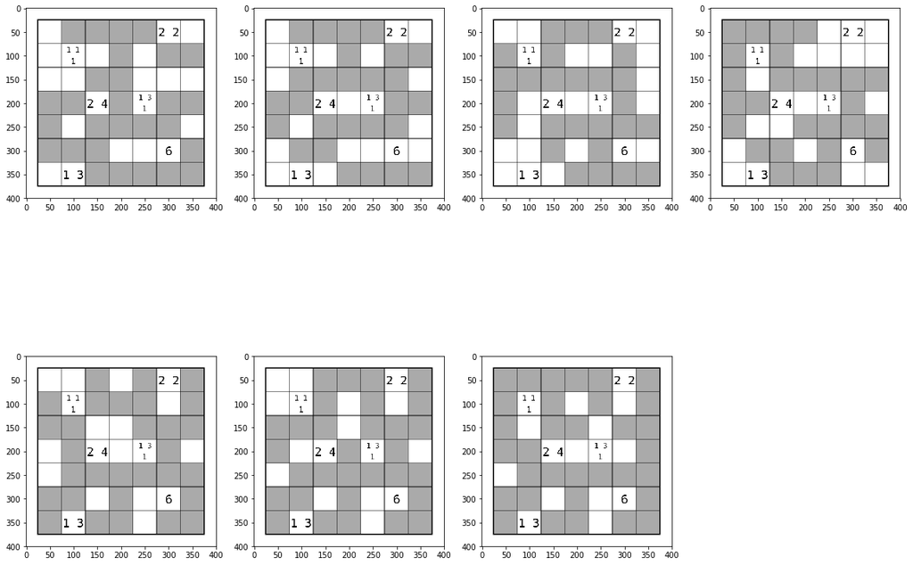

```python
ins = sample_instances[3]
sga = SGA(ins, func=lambda x: -objective_function(x, ins)); d = ins.size ** 2; sga.solve(
    number_of_iterations=250,
    population_size=20 * d,
    crossover_probability=0.95,
    mutation_probability=0.1,
    crossover_method=rowcolumn_crossover,
    mutation_method=simple_mutation,
    log_frequency=10,
    title='SGA z operatorami wierszowymi'
)
sga.show_stats()
sga.show_individuals(figsize=(20,15))
```

### Local crossover operators

We would want to have an influence on cells around clues. New operator will exchange blocks around hints, where mutation will change layout around a hint.

```python
def layout_from_list(layout):
    a = list(layout[:3])
    b = [layout[3]]
    c = list(layout[4:-1][::-1])
    d = [layout[-1]]
    return a+d+b+c
```

```python
LAYOUTS_8 = {}
possible_counts = chain(
    combinations(range(0,9), 1),
    combinations_with_replacement(range(1,6), 2),
    combinations_with_replacement(range(1,4), 3),
    combinations_with_replacement(range(1,2), 4))
layouts = list(product(range(2), repeat=8))

for layout, hint in product(layouts, possible_counts):
    if fit(hint, layout, strict=False):
        if hint not in LAYOUTS_8:
            LAYOUTS_8[hint] = []
        ll = layout_from_list(layout)

        LAYOUTS_8[hint].append(np.array(ll[:4] + [0] + ll[4:]).reshape((3,3)))
```

```python
def clue_crossover(instance, p, q):
    p = p.reshape((instance.size, -1))
    q = q.reshape((instance.size, -1))
    cnt = np.random.choice(len(instance.hints))
    ids = np.random.choice(len(instance.hints) + 1, cnt, replace=False)
    w = np.zeros_like(p)
    v = np.zeros_like(q)
    covered = np.zeros_like(p)
    for idx, (coord, hint) in enumerate(zip(instance.coords, instance.hints)):
        x, y = coord
        p_layout = p[
                    max(0, x - 1):min(instance.size, x + 1 + 1),
                    max(0, y - 1):min(instance.size, y + 1 + 1)
                    ]
        q_layout = q[
                    max(0, x - 1):min(instance.size, x + 1 + 1),
                    max(0, y - 1):min(instance.size, y + 1 + 1)
                    ]
        if idx in ids:
            w[max(0, x - 1):min(instance.size, x + 1 + 1), max(0, y - 1):min(instance.size, y + 1 + 1)] = q_layout
            v[max(0, x - 1):min(instance.size, x + 1 + 1), max(0, y - 1):min(instance.size, y + 1 + 1)] = p_layout

        else:
            w[max(0, x - 1):min(instance.size, x + 1 + 1), max(0, y - 1):min(instance.size, y + 1 + 1)] = p_layout
            v[max(0, x - 1):min(instance.size, x + 1 + 1), max(0, y - 1):min(instance.size, y + 1 + 1)] = q_layout

        covered[
            max(0, x - 1):min(instance.size, x + 1 + 1),
            max(0, y - 1):min(instance.size, y + 1 + 1)
        ] = 1

    not_crossed = np.vstack(np.where(covered == 0))
    k = np.random.choice(len(not_crossed) + 1)
    ids = np.random.choice(len(not_crossed), k, replace=False)

    for idx in range(len(not_crossed)):
        x, y = not_crossed[:, idx]

        if idx in ids:
            w[x, y] = q[x, y]
            v[x, y] = p[x, y]

        else:
            w[x, y] = p[x, y]
            v[x, y] = q[x, y]

    return w.reshape(-1), v.reshape(-1)


def clue_mutation(instance, p, ppb):
    q = p.copy().reshape((instance.size, -1))
    covered = np.zeros_like(q)
    for coord, hint in zip(instance.coords, instance.hints):
        x, y = coord
        covered[
            max(0, x - 1):min(instance.size, x + 1 + 1),
            max(0, y - 1):min(instance.size, y + 1 + 1)
        ] = 1
        if np.random.random() < ppb:
            t_hint = tuple(sorted(hint))
            if 0 < x < instance.size - 1 and 0 < y < instance.size - 1:

                k = len(LAYOUTS_8[t_hint])
                idx = np.random.choice(k)

                mutated_part = LAYOUTS_8[t_hint][idx]
                q[x-1:x+2, y-1:y+2] = mutated_part

            elif x == 0 and y == 0:
                correct_layouts = [d for d in LAYOUTS_8[t_hint] if d[:, 0].sum() == 0 and d[0, :].sum() == 0]
                k = len(correct_layouts)
                idx = np.random.choice(k)
                mutated_part = correct_layouts[idx]
                q[0:2, 0:2] = mutated_part[1:, 1:]

            elif x == 0 and y == instance.size - 1:
                correct_layouts = [d for d in LAYOUTS_8[t_hint] if d[0, :].sum() == 0 and d[:, -1].sum() == 0]
                k = len(correct_layouts)
                idx = np.random.choice(k)
                mutated_part = correct_layouts[idx]
                q[0:2, -2:] = mutated_part[1:, :-1]

            elif x == 0:
                correct_layouts = [d for d in LAYOUTS_8[t_hint] if d[0, :].sum() == 0]
                k = len(correct_layouts)
                idx = np.random.choice(k)
                mutated_part = correct_layouts[idx]
                q[:2, y-1:y+2] = mutated_part[1:, :]

            elif x == instance.size - 1 and y == 0:
                correct_layouts = [d for d in LAYOUTS_8[t_hint] if d[:, 0].sum() == 0 and d[-1, :].sum() == 0]
                k = len(correct_layouts)
                idx = np.random.choice(k)
                mutated_part = correct_layouts[idx]

                q[x-1:, :2] = mutated_part[:-1, 1:]

            elif x == instance.size - 1 and y == instance.size - 1:
                correct_layouts = [d for d in LAYOUTS_8[t_hint] if d[-1, :].sum() == 0 and d[:, -1].sum() == 0]
                k = len(correct_layouts)
                idx = np.random.choice(k)
                mutated_part = correct_layouts[idx]
                q[-2:, -2:] = mutated_part[:-1, :-1]

            elif x == instance.size - 1:
                correct_layouts = [d for d in LAYOUTS_8[t_hint] if d[-1, :].sum() == 0]
                k = len(correct_layouts)
                idx = np.random.choice(k)
                mutated_part = correct_layouts[idx]
                q[-2:, y-1:y+2] = mutated_part[:-1, :]

            elif y == 0:
                correct_layouts = [d for d in LAYOUTS_8[t_hint] if d[:,  0].sum() == 0]
                k = len(correct_layouts)
                idx = np.random.choice(k)
                mutated_part = correct_layouts[idx]
                q[x-1:x+2, :2] = mutated_part[:, 1:]

            elif y == instance.size - 1:
                correct_layouts = [d for d in LAYOUTS_8[t_hint] if d[:,  -1].sum() == 0]
                k = len(correct_layouts)
                idx = np.random.choice(k)
                mutated_part = correct_layouts[idx]
                q[x-1:x+2, -2:] = mutated_part[:, :-1]

    not_crossed = np.vstack(np.where(covered == 0)).T
    for x, y in not_crossed:
        if np.random.random() < ppb:
            q[x, y] = 1 - q[x, y]

    return q.reshape(-1)
```

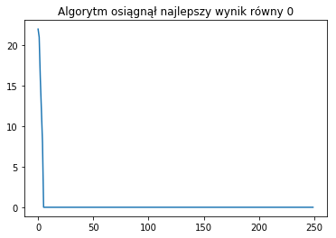

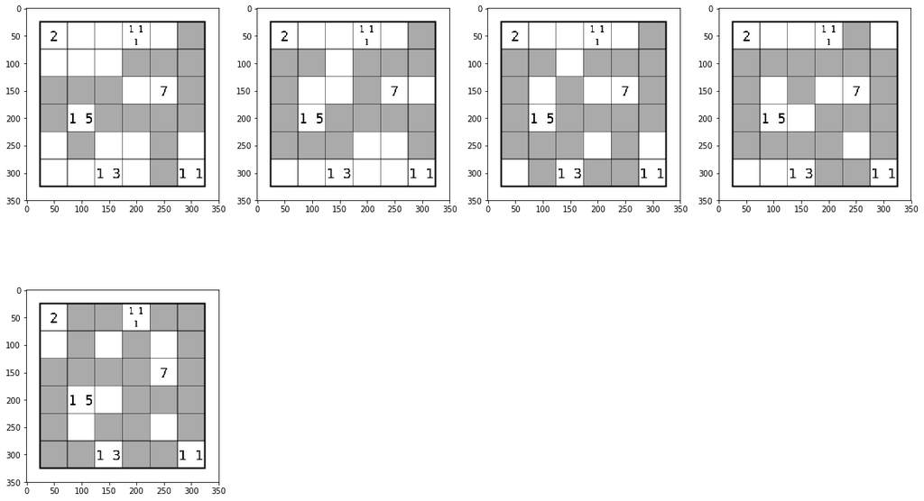

```python
ins = sample_instances[1]
sga = SGA(ins, func=lambda x: -objective_function(x, ins)); d = ins.size ** 2; sga.solve(
    number_of_iterations=250,
    population_size=20 * d,
    crossover_probability=0.95,
    mutation_probability=0.1,
    crossover_method=lambda p, q: clue_crossover(ins, p, q),
    mutation_method=lambda p, q: clue_mutation(ins, p, q),
    log_frequency=10,
    title='SGA z operatorami na wskazówkach'
)
sga.show_stats()
sga.show_individuals()
```

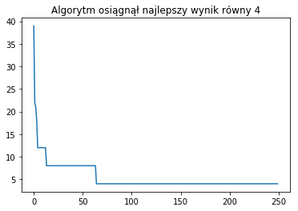

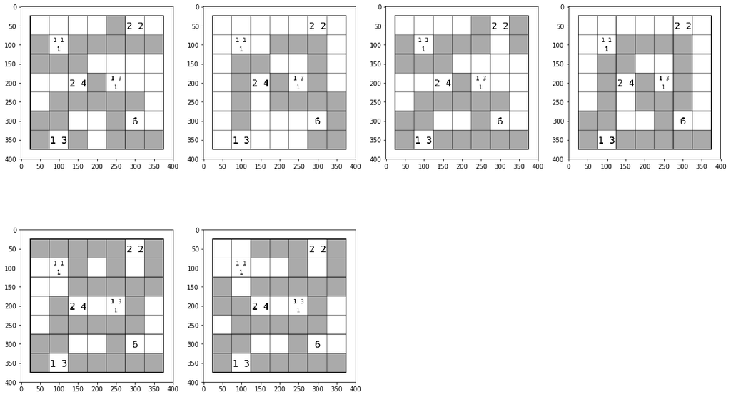

```python
ins = sample_instances[3]
sga = SGA(ins, func=lambda x: -objective_function(x, ins)); d = ins.size ** 2; sga.solve(
    number_of_iterations=250,
    population_size=20 * d,
    crossover_probability=0.95,
    mutation_probability=0.1,
    crossover_method=lambda p, q: clue_crossover(ins, p, q),
    mutation_method=lambda p, q: clue_mutation(ins, p, q),
    log_frequency=10,
    title='SGA z operatorami na wskazówkach'
)
sga.show_stats()
sga.show_individuals()
```

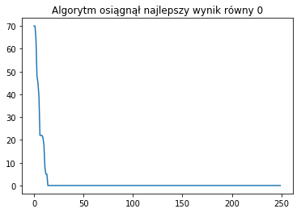

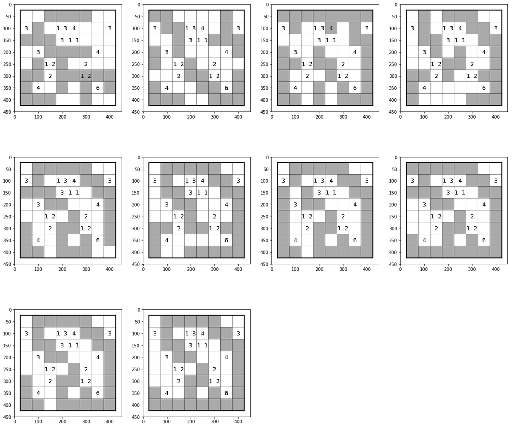

```python
ins = sample_instances[9]
sga = SGA(ins, func=lambda x: -objective_function(x, ins)); d = ins.size ** 2; sga.solve(
    number_of_iterations=250,
    population_size=20 * d,
    crossover_probability=0.95,
    mutation_probability=0.1,
    crossover_method=lambda p, q: clue_crossover(ins, p, q),
    mutation_method=lambda p, q: clue_mutation(ins, p, q),
    log_frequency=10,
    title='SGA z operatorami na wskazówkach'
)
sga.show_stats()
sga.show_individuals(figsize=(20,18))
```

### Crossover operators comparison

For each introduced crossover operator we'll count have many better children it produced while collaborating with mutation operator.

```python
ins = sample_instances[10]

crossover_operators = [
    simple_crossover,
    multipoint_crossover,
    rowcolumn_crossover,
    lambda p, q: clue_crossover(ins, p, q)
]
mutation_operators = [
    simple_mutation,
    lambda p, q: clue_mutation(ins, p, q)
]

cross_op_descs = ['Simple', 'Multipoint', 'Row/column', 'Clue']
mut_op_descs = ['Simple', 'Clue']
```

```python
responses = []
for (cross_op, mut_op), (cx_desc, mut_desc) in zip(product(crossover_operators, mutation_operators), product(cross_op_descs, mut_op_descs)):
    desc = '{} crossover with {} mutation'.format(cx_desc, mut_desc)
    sga = SGA(ins, func=lambda x: -objective_function(x, ins)); d = ins.size ** 2; sga.solve(
        number_of_iterations=250,
        population_size= 1000,
        crossover_probability=0.95,
        mutation_probability=0.1,
        crossover_method=cross_op,
        mutation_method=mut_op,
        log_frequency=10,
        title=desc,
        max_found_solutions=1000
    )
    responses.append([sga.successfull_crossovers, sga.costs, desc])
```

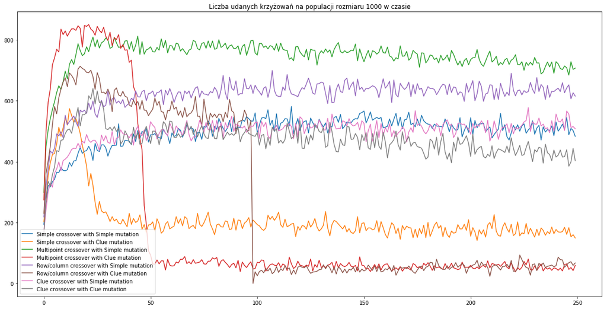

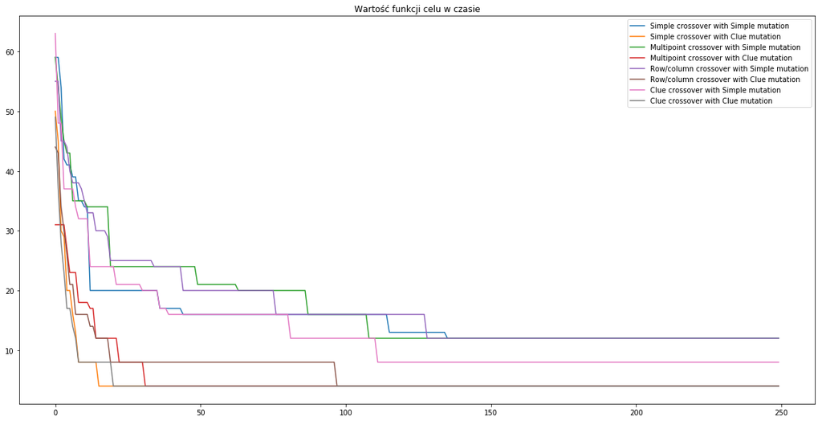

```python
plt.figure(figsize=(20, 10))
for (line, _, desc) in responses:
    plt.title('Liczba udanych krzyżowań na populacji rozmiaru 1000 w czasie')
    plt.plot(line, label=desc)
    plt.legend()

plt.figure(figsize=(20, 10))
for (_, line, desc) in responses:
    plt.title('Wartość funkcji celu w czasie')
    plt.plot(line, label=desc)
    plt.legend()
```

## Approach no. 3: SGA with refreshing population

We introduce a new parameter: if the best value of objective function wasn't improved after $W$ iterations, few of layouts around clues in half of populutation with another, correct layouts.

```python
def repair_mutant(instance, X, k = 5):
    k = min(k, len(instance.coords))
    p = np.zeros((instance.size + 2, instance.size + 2), dtype=int)
    p[1:-1, 1:-1] = X.copy().reshape((instance.size, -1))
    bad = []
    good = []
    for idx, ((x, y), hint) in enumerate(zip(instance.coords, instance.hints)):
        t_hint = tuple(sorted(hint))
        if not any([(p[x:x+3, y:y+3] == d).all() for d in LAYOUTS_8[t_hint]]):
            bad.append(idx)
        else: good.append(idx)

    if len(bad) < k:
        indices = np.concatenate([np.array(bad, dtype=int), np.random.choice(len(good), k - len(bad), replace=False)])
    else:
        indices = np.random.choice(len(bad), k, replace=False)

    for clue_id in indices:

        t_hint = tuple(sorted(instance.hints[clue_id]))
        m = len(LAYOUTS_8[t_hint])
        indices = np.random.choice(m, m)
        x, y = instance.coords[clue_id]
        for idx in indices:
            p[x:x+3, y:y+3] = LAYOUTS_8[t_hint][idx]
            if np.concatenate([p[0, :], p[-1, :], p[:, 0], p[:, -1]]).sum() == 0:
                fit = True
                break

    return p[1:-1, 1:-1].reshape(-1)
```

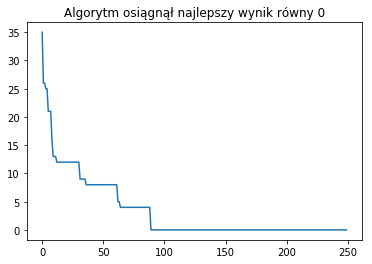

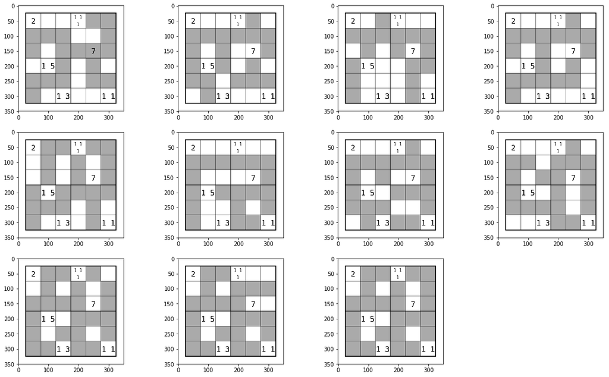

```python
ins = sample_instances[1]
sga = SGA(ins, func=lambda x: -objective_function(x, ins)); d = ins.size ** 2; sga.solve(
    number_of_iterations=250,
    population_size=20 * d,
    crossover_probability=0.9,
    mutation_probability=0.1,
    crossover_method=multipoint_crossover,
    mutation_method=simple_mutation,
    log_frequency=10,
    reset_on_stuck=True,
    reset_function=repair_mutant,
    reset_after=25,
    title='SGA z prostymi operatorami'
)
sga.show_stats()
sga.show_individuals()
```

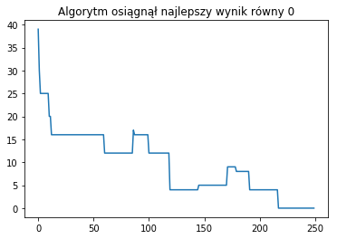

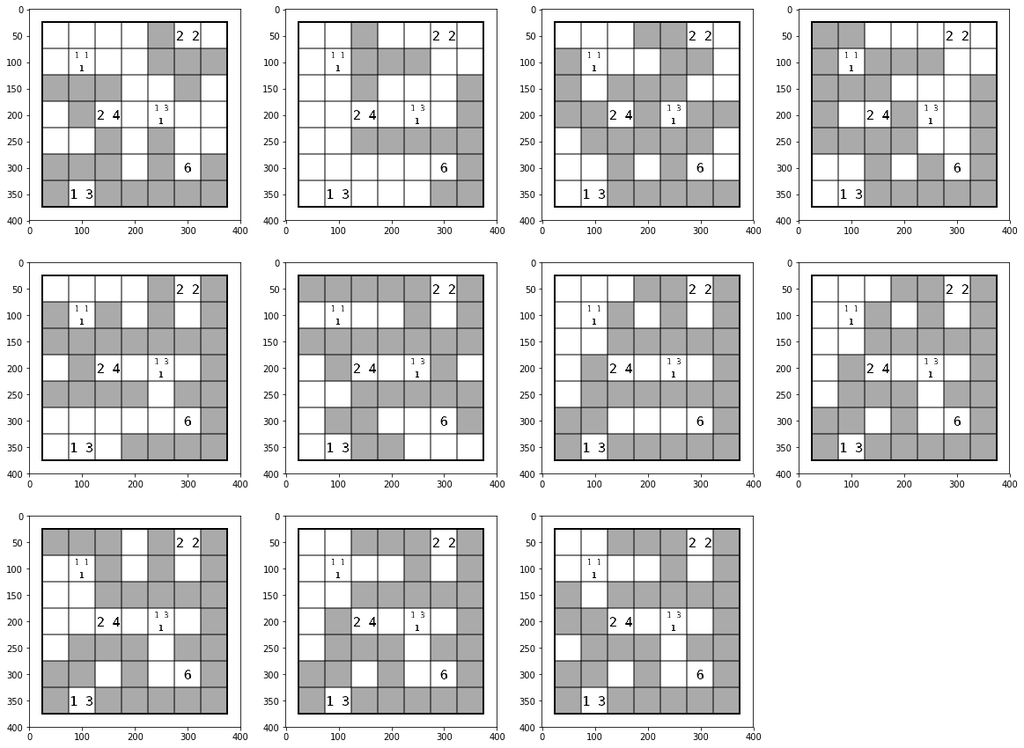

```python
ins = sample_instances[3]
sga = SGA(ins, func=lambda x: -objective_function(x, ins)); d = ins.size ** 2; sga.solve(
    number_of_iterations=250,
    population_size=20 * d,
    crossover_probability=0.9,
    mutation_probability=0.1,
    crossover_method=multipoint_crossover,
    mutation_method=simple_mutation,
    log_frequency=10,
    reset_on_stuck=True,
    reset_function=repair_mutant,
    reset_after=25,
    title='SGA z prostymi operatorami'
)
sga.show_stats()
sga.show_individuals(figsize=(20,15))
```

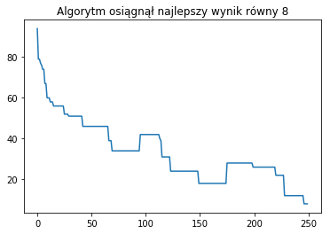

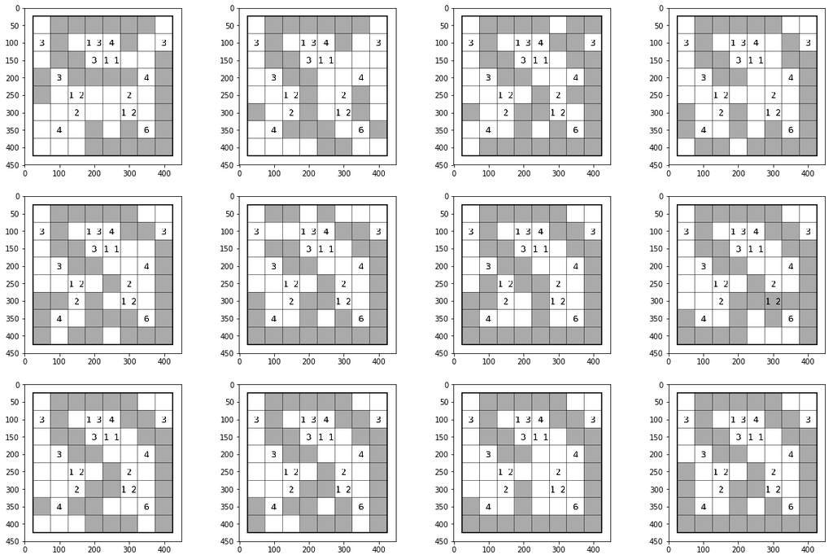

```python
ins = sample_instances[9]
sga = SGA(ins, func=lambda x: -objective_function(x, ins)); d = ins.size ** 2; sga.solve(
    number_of_iterations=250,
    population_size=20 * d,
    crossover_probability=0.9,
    mutation_probability=0.1,
    crossover_method=multipoint_crossover,
    mutation_method=simple_mutation,
    log_frequency=10,
    reset_on_stuck=True,
    reset_function=repair_mutant,
    reset_after=25,
    title='SGA z prostymi operatorami'
)
sga.show_stats()
sga.show_individuals(figsize=(20,18))
```

## Approach no. 4: SGA with new encoding

This time we store information around a clue, instead of remembering single bits. Let $k$ be a number of clues in an instance. Then a genotype will contain $k$ numbers indicating one of possible layout for each clue. Additionally, next $k$ numbers will encode an order in which corresponding clues lay one above another with permutation (since layouts for overlapping clues can exclude each other). Last $m$ bits encode uncovered by clues cells in a way like in the previous approaches.

```python
def split(p, instance):
        return p[:len(instance.hints)], p[len(instance.hints) : 2 * len(instance.hints)], p[2 * len(instance.hints):]

def compose(layouts, order, rest):
    return np.concatenate([layouts, order, rest])

def PMXx(ind1, ind2, i=None, j=None):
    offspring = np.full_like(ind1, fill_value=-1)
    if i is None or j is None:
        a = np.random.choice(len(ind1), 2, False)
        i, j = a.min(), a.max()
    offspring[i:j+1] = ind1[i:j+1]
    for idx in range(i,j+1):
        allel = ind2[idx]
        if allel not in ind1[i:j+1]:
            V = ind1[idx]
            idx = np.argmax(ind2==V)
            seen = {}
            while idx in range(i, j+1):
                if idx in seen:
                    break
                seen[idx] = 1

                V = ind1[idx]
                idx = np.argmax(ind2==V)

            offspring[idx] = allel

    offspring[offspring==-1] = ind2[offspring==-1]

    return offspring

def PMX(ind1, ind2):
    return PMXx(ind1, ind2), PMXx(ind2, ind1)

def transposition_mutation(p):
    i, j = np.random.choice(len(p), 2, False)
    q = p.copy()
    q[i] = p[j]
    q[j] = p[i]
    return q

def simple_crossover2(instance, p, q):
    l_ids1, order1, bits1 = split(p, instance)
    l_ids2, order2, bits2 = split(q, instance)
    l1, l2 = simple_crossover(np.array(l_ids1), np.array(l_ids2))
    if len(instance.hints) > 1:
        o1, o2 = PMX(order1, order2)
    else:
        o1 = o2 = [0]
    b1, b2 = multipoint_crossover(bits1, bits2)

    return compose(l1, o1, b1), compose(l2, o2, b2)

def order_mutation(instance, p, ppb):
    l_ids, order, bits = split(p, instance)
    for idx in range(len(instance.hints)):
        if np.random.random() < ppb:
            l_ids[idx] = np.random.choice(len(LAYOUTS_8[tuple(sorted(instance.hints[idx]))]))

        if np.random.random() < ppb and len(order) > 1:
            order = transposition_mutation(order)

    bits = simple_mutation(bits, ppb)
    return compose(l_ids, order, bits)


def get_not_covered(instance):
    grid = np.zeros((instance.size, instance.size))
    for x,y in instance.coords:
        grid[max(0, x-1):min(instance.size,x+2),
             max(0, y-1):min(instance.size,y+2)] = 1

    x, y = np.where(grid == 0)

    return np.vstack([x,y]).T

def unroll(instance, p):
    grid = np.full((instance.size + 2, instance.size + 2), dtype=int, fill_value=5)
    grid[0, :] = 0
    grid[-1, :] = 0
    grid[:, 0] = 0
    grid[:, -1] = 0
    score = 0

    layout_ids, order, rest = split(p, instance)

    hints = np.array(instance.hints)[order]
    coords = np.array(instance.coords)[order]
    layout_ids = layout_ids[order]

    overlapping_parts = 0
    for layout_id, (x,y), hint in zip(layout_ids, coords, hints):

        t_hint = tuple(sorted(hint))
        layout = LAYOUTS_8[t_hint][layout_id]

        grid_part = grid[x:x+3, y:y+3].copy()
        grid[x:x+3, y:y+3] = layout

    for (x,y), bit in zip(get_not_covered(instance), rest):
        grid[x + 1, y + 1] = bit

    return grid[1:-1, 1:-1]
```

Objective function is modified as well - we want to punish situations, where two layouts in an individual are excluding each other.

```python
OVERLAPPING_LAYOUT_PENALTY = 4
```

```python
def modified_objective_function(p, instance):
    grid = np.full((instance.size + 2, instance.size + 2), dtype=int, fill_value=5)
    grid[0, :] = 0
    grid[-1, :] = 0
    grid[:, 0] = 0
    grid[:, -1] = 0
    score = 0

    layout_ids, order, rest = split(p, instance)

    hints = np.array(instance.hints)[order]
    coords = np.array(instance.coords)[order]
    layout_ids = layout_ids[order]

    overlapping_parts = 0
    for layout_id, (x,y), hint in zip(layout_ids, coords, hints):

        t_hint = tuple(sorted(hint))
        layout = LAYOUTS_8[t_hint][layout_id]

        grid_part = grid[x:x+3, y:y+3].copy()
        if (np.abs(grid_part - layout) == 1).sum() > 0:  # overlaps any pattern or border
            overlapping_parts += 1

        grid[x:x+3, y:y+3] = layout

    score = -overlapping_parts * OVERLAPPING_LAYOUT_PENALTY

    for (x,y), bit in zip(get_not_covered(instance), rest):
        grid[x + 1, y + 1] = bit

    score += objective_function(grid[1:-1, 1:-1], instance)
    return score
```

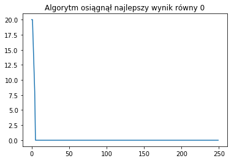

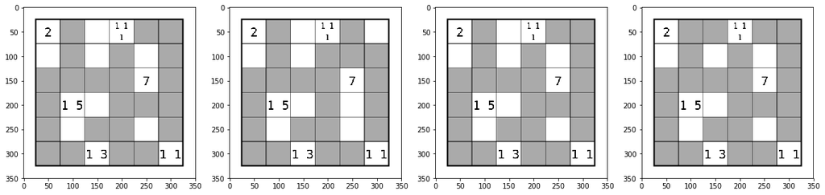

```python
ins = sample_instances[1]
sga = SGA(ins, func=lambda x: -modified_objective_function(x, ins)); d = ins.size ** 2; sga.solve(
    number_of_iterations=250,
    population_size=20 * d,
    individual_constructor=lambda instance: np.concatenate([
                np.array([np.random.choice(len(LAYOUTS_8[tuple(sorted(h))])) for h in instance.hints]),
                np.random.permutation(len(instance.hints)),
                np.random.choice(2, get_not_covered(instance).shape[0])
            ]),
    crossover_probability=0.95,
    mutation_probability=0.05,
    crossover_method=lambda p, q: simple_crossover2(ins, p, q),
    mutation_method=lambda p, q: order_mutation(ins, p, q),
    log_frequency=10,
    title='SGA z kodowaniem układów'
)
sga.show_stats()
sga.show_individuals(figsize=(20,12), unroll_func=unroll)
```

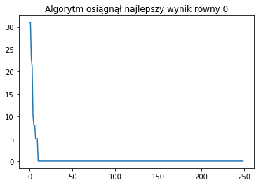

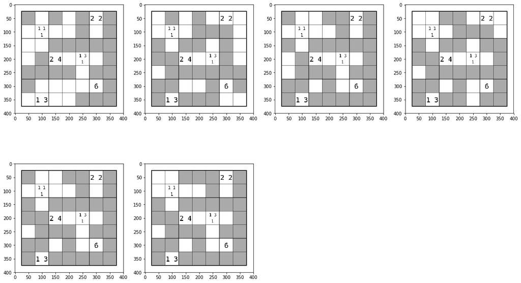

```python
ins = sample_instances[3]
sga = SGA(ins, func=lambda x: -modified_objective_function(x, ins)); d = ins.size ** 2; sga.solve(
    number_of_iterations=250,
    population_size=20 * d,
    individual_constructor=lambda instance: np.concatenate([
                np.array([np.random.choice(len(LAYOUTS_8[tuple(sorted(h))])) for h in instance.hints]),
                np.random.permutation(len(instance.hints)),
                np.random.choice(2, get_not_covered(instance).shape[0])
            ]),
    crossover_probability=0.95,
    mutation_probability=0.05,
    crossover_method=lambda p, q: simple_crossover2(ins, p, q),
    mutation_method=lambda p, q: order_mutation(ins, p, q),
    log_frequency=10,
    title='SGA z kodowaniem układów'
)
sga.show_stats()
sga.show_individuals(figsize=(20,12), unroll_func=unroll)
```

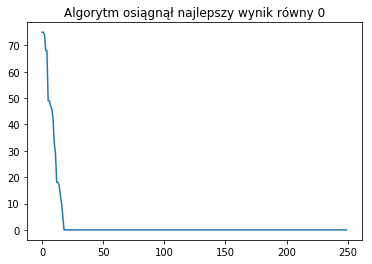

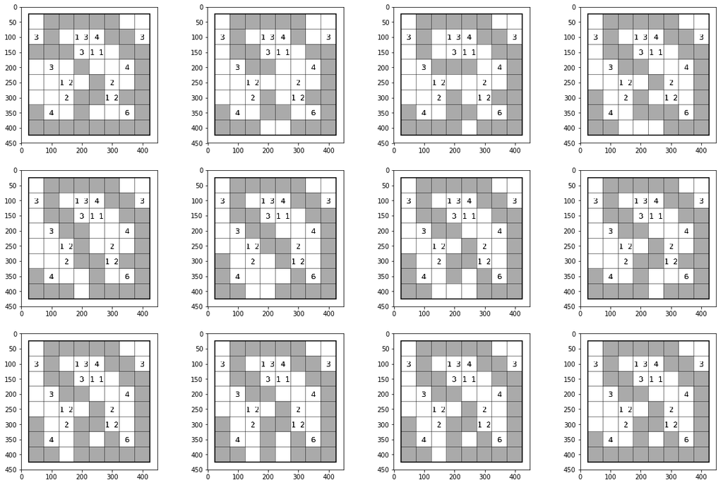

```python
ins = sample_instances[9]
sga = SGA(ins, func=lambda x: -modified_objective_function(x, ins)); d = ins.size ** 2; sga.solve(
    number_of_iterations=250,
    population_size=20 * d,
    individual_constructor=lambda instance: np.concatenate([
                np.array([np.random.choice(len(LAYOUTS_8[tuple(sorted(h))])) for h in instance.hints]),
                np.random.permutation(len(instance.hints)),
                np.random.choice(2, get_not_covered(instance).shape[0])
            ]),
    crossover_probability=0.95,
    mutation_probability=0.05,
    crossover_method=lambda p, q: simple_crossover2(ins, p, q),
    mutation_method=lambda p, q: order_mutation(ins, p, q),
    log_frequency=10,
    title='SGA z kodowaniem układów'
)
sga.show_stats()
sga.show_individuals(figsize=(20,18), unroll_func=unroll)
```

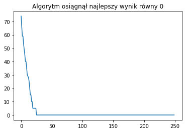

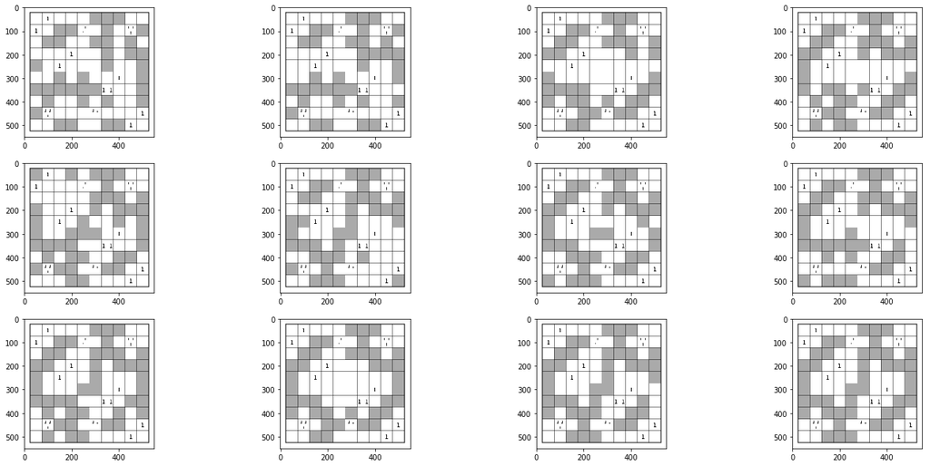

```python
ins = sample_instances[-4]
sga = SGA(ins, func=lambda x: -modified_objective_function(x, ins)); d = ins.size ** 2; sga.solve(
    number_of_iterations=250,
    population_size=20 * d,
    individual_constructor=lambda instance: np.concatenate([
                np.array([np.random.choice(len(LAYOUTS_8[tuple(sorted(h))])) for h in instance.hints]),
                np.random.permutation(len(instance.hints)),
                np.random.choice(2, get_not_covered(instance).shape[0])
            ]),
    crossover_probability=0.95,
    mutation_probability=0.05,
    crossover_method=lambda p, q: simple_crossover2(ins, p, q),
    mutation_method=lambda p, q: order_mutation(ins, p, q),
    log_frequency=10,
    title='SGA z kodowaniem układów'
)
sga.show_stats()
sga.show_individuals(figsize=(24,15), unroll_func=unroll)
```

## Tests

We generate 100 grid from 6x6 to 9x9 and check how proposed approaches performs on them. Instances will be created with $SGA$ - we just order to solve and empty grid, then we'll add a few hints to it.

```python
def make_instance_from_solution(size, ind):
    ind = ind.reshape((size, size))
    embed = np.zeros((size + 2, size + 2), dtype=np.int64)
    embed[1:-1, 1:-1] = ind

    zeros = np.vstack([*np.where(ind == 0)]).T
    hints_count = np.random.choice(range(size, 3 * size // 2))
    cell_ids = np.random.choice(zeros.shape[0], hints_count, replace=False)
    hints_positions = zeros[cell_ids] + 1

    hints_collection = []
    hints_coords = []

    for x, y in hints_positions:
        neighbourhood = np.concatenate([embed[x - 1, y - 1:y + 2], [embed[x, y + 1]], embed[x + 1, y - 1:y + 2][::-1], [embed[x, y - 1]]])
        hint = []
        if neighbourhood.sum() == 8:
            hint = [8]
        else:
            first_zero_position = np.where(neighbourhood == 0)[0][0]
            shifted_neighbourhood = np.concatenate([neighbourhood, neighbourhood])[first_zero_position : first_zero_position + 8]
            index = 0
            while index < 8:
                if shifted_neighbourhood[index] == 0:
                    index += 1
                    continue
                length = 0
                while index < 8 and shifted_neighbourhood[index] == 1:
                    index += 1
                    length += 1

                hint.append(length)

            if len(hint) == 0:
                hint = [0]

        hints_collection.append(sorted(hint))
        hints_coords.append([x - 1, y - 1])

    return TapaInstance(size=size, coords=hints_coords, hints=hints_collection)
```

```python
def generate_instances(size=6, count=15):
    ins = TapaInstance(size=size, hints=[], coords=[])
    d = ins.size ** 2
    sga = SGA(ins, func=lambda x: -objective_function(x, ins))
    sga.solve(
        number_of_iterations = 250,
        population_size=40 * count * d,
        crossover_probability=0.95,
        mutation_probability=0.1,
        crossover_method=lambda p, q: multipoint_crossover(p, q),
        mutation_method=lambda p, q: simple_mutation(p, q),
        log_frequency=10,
        max_found_solutions=count,
        verbose=False,
        title='Generating {} instances {}x{}'.format(count, size, size)
    )
    generated_instances = []
    for i in range(count):
        instance = make_instance_from_solution(size=size, ind=sga.last_population[i, :])
        generated_instances.append(instance)

    return generated_instances, sga.last_population[:count, :]
```

```python
testing_instances = {
    '{}x{}'.format(i,i): generate_instances(i, 25) for i in range(6, 10)
}

save(testing_instances, 'tests.pickle')
```

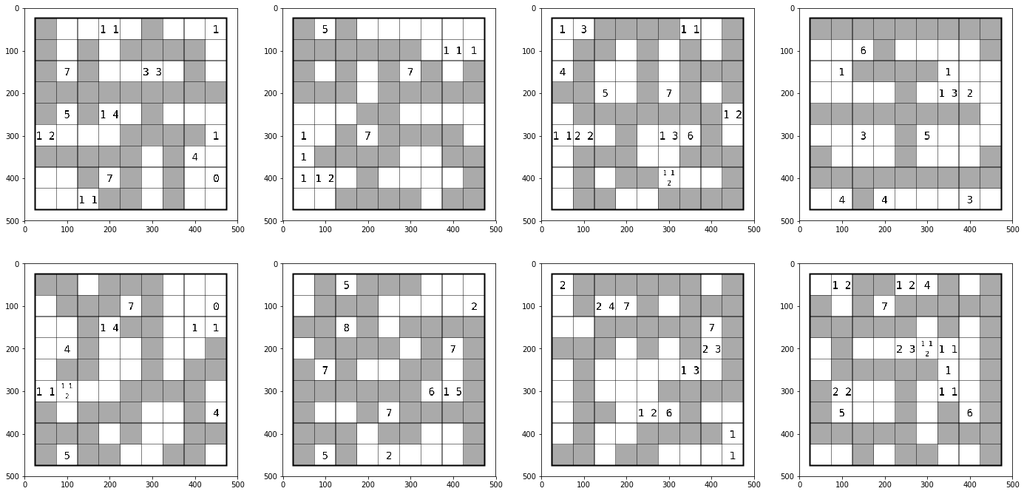

```python
selected9x9 = testing_instances['9x9']
cnt = 8
show_grids(selected9x9[0][:cnt], selected9x9[1][:cnt], figsize=(24,18))
```

### PBIL

```python
pbil_responses = {}
for size in sorted(testing_instances):
    pbil_responses[size] = []
    instances, _ = testing_instances[size]
    for instance in tqdm_notebook(instances, desc='PBIL on {}'.format(size)):
        d=instance.size ** 2
        pbil = PBIL(
            d=d,
            N=40 * d,
            iterations=250,
            function=lambda x: objective_function(x, instance),
            theta1=0.1,
            theta2=0.05,
            theta3=0.01,
            log_frequency=50,
            instance=instance)
        pbil.solve(verbose=False, no_tqdm=True)

        pbil_responses[size].append(pbil.best_score == 0)
save(pbil_responses, 'pbil_responses.pickle')
```

### SGA with multipoint crossover and simple mutation

```python
sga_responses = {}
for size in sorted(testing_instances):
    sga_responses[size] = []
    instances, _ = testing_instances[size]
    for instance in tqdm_notebook(instances, desc='SGA z prostymi operatorami on {}'.format(size)):
        sga = SGA(instance, func=lambda x: -objective_function(x, instance)); d = instance.size ** 2; sga.solve(
            number_of_iterations=250,
            population_size=40 * d,
            crossover_probability=0.9,
            mutation_probability=0.1,
            crossover_method=multipoint_crossover,
            mutation_method=simple_mutation,
            log_frequency=10,
            no_tqdm=True
        )
        sga_responses[size].append(sga.best_score == 0)
save(sga_responses, 'sga_responses.pickle')
```

### SGA with multipoint crossover and simple mutation and population refreshing

```python
refreshing_sga_responses = {}
for size in sorted(testing_instances):
    refreshing_sga_responses[size] = []
    instances, _ = testing_instances[size]
    for instance in tqdm_notebook(instances, desc='SGA z wybijaniem on {}'.format(size)):
        sga = SGA(instance, func=lambda x: -objective_function(x, instance)); d = instance.size ** 2; sga.solve(
            number_of_iterations=250,
            population_size=40 * d,
            crossover_probability=0.9,
            mutation_probability=0.1,
            crossover_method=multipoint_crossover,
            mutation_method=simple_mutation,
            log_frequency=10,
            reset_on_stuck=True,
            reset_function=repair_mutant,
            reset_after=25,
            no_tqdm=True
        )
        refreshing_sga_responses[size].append(sga.best_score == 0)
save(refreshing_sga_responses, 'sga_refresh.pickle')
```

### SGA with layouts encoding

```python
sgav2_responses = {}
for size in sorted(testing_instances):
    sgav2_responses[size] = []
    instances, _ = testing_instances[size]
    for instance in tqdm_notebook(instances, desc='SGA v2 on {}'.format(size)):
        sga = SGA(instance, func=lambda x: -modified_objective_function(x, instance)); d = instance.size ** 2; sga.solve(
            number_of_iterations=250,
            population_size=40 * d,
            individual_constructor=lambda _: np.concatenate([
                        np.array([np.random.choice(len(LAYOUTS_8[tuple(sorted(h))])) for h in instance.hints]),
                        np.random.permutation(len(instance.hints)),
                        np.random.choice(2, get_not_covered(instance).shape[0])
                    ]),
            crossover_probability=0.95,
            mutation_probability=0.05,
            crossover_method=lambda p, q: simple_crossover2(instance, p, q),
            mutation_method=lambda p, q: order_mutation(instance, p, q),
            log_frequency=10,
            title='SGA z kodowaniem układów',
            no_tqdm=True
        )

        sgav2_responses[size].append(sga.best_score == 0)
save(sgav2_responses, 'sgav2.pickle')
```

```python
def save(obj, filename):
    f = open(filename,'wb+')
    pickle.dump(obj, f)
    f.close()

def load(filename):
    f = open(filename,'rb')
    obj = pickle.load(f)
    f.close()
    return obj
```

```python
pbil_responses = load('pbil_responses.pickle')
sga_responses = load('sga_responses.pickle')
refreshing_sga_responses = load('sga_refresh.pickle')
sgav2_responses = load('sgav2.pickle')
```

```python
import pandas as pd

partial_dfs = []
for response, alg_name in zip([pbil_responses, sga_responses, refreshing_sga_responses, sgav2_responses],
                              ['PBIL', 'SGA with simple operators', 'SGA with refreshing', 'SGA with new encoding']):
    response = [sum(response[k]) for k in sorted(response)]
    response.append(sum(response))
    df_tmp = pd.DataFrame.from_dict({alg_name : response}, orient='index')
    partial_dfs.append(df_tmp)

final_df = pd.concat(partial_dfs)
final_df.rename(columns = {0: '6x6', 1: '7x7', 2: '8x8', 3: '9x9', 4: 'Total'})
```

|  | 6x6 | 7x7 | 8x8 | 9x9 | Total |
| --- | --- | --- | --- | --- | --- |
| PBIL | 19 | 16 | 7 | 5 | 47 |
| SGA with simple operators | 25 | 24 | 6 | 0 | 55 |
| SGA with refreshing | 25 | 24 | 11 | 4 | 64 |
| SGA with new encoding | 24 | 25 | 24 | 24 | 97 |

Solving time

[output not shown]